# A summary of the tweets generated at the 2015 Evolution meeting

François Michonneau

## About this document

This document was generated using RMarkdown, and the source is available on GitHub at: https://github.com/fmichonneau/evol2015-tweets.

Pull requests to add other figures or fix bugs are welcome.

The dataset used here is available as a CSV file from [figshare](http://figshare.com/articles/Evolution_2015_tweets/1470180).

This document (and associated code) is released under a CC0 licence.

If you have questions or comments, I am on twitter at fmic_ or by email at francois.michonneau@gmail.com

## Basic summary

- Total number of tweets with the #Evol2015 hashtag between June 22nd, and July 1st 2015: 6846.
- Total of original tweets (no retweets): 2614.
- Number of users who tweeted: 987.

## The 5 most favorited tweets

> Sporting dueling rock-inspired t-shirts– Noor & Turelli #Evol2015 http://t.co/VAzwWElZDo

> — mafnoor | [2015-06-27](https://twitter.com/mafnoor/status/614844259133472768) | 64 retweets, 124 favorites.

> I wonder if future phylogeographers will infer national park boundaries as “refugia during the Anthropocene” #evol2015

> — omearabrian | [2015-06-28](https://twitter.com/omearabrian/status/615133905415467008) | 46 retweets, 74 favorites.

> Great ideas coming out of #Evol2015 #WomenInScience breakout groups! http://t.co/FKU6nAdzUJ

> — CorrieMoreau | [2015-06-27](https://twitter.com/CorrieMoreau/status/614803096246558720) | 11 retweets, 37 favorites.

> #Evol2015 Councils pursuing Evolution 2019 to be in Providence, RI, if possible… not set yet. 16-Austin, 17-Portland, 18-France all set.

> — mafnoor | [2015-06-26](https://twitter.com/mafnoor/status/614431435194298368) | 31 retweets, 32 favorites.

> I feel the need to point out that I’m tweeting for the first time, at Evolution, on an iPad I won from a group of Creationists. #Evol2015

> — MikeWiser2 | [2015-06-27](https://twitter.com/MikeWiser2/status/614851176983588864) | 8 retweets, 31 favorites.

## The 5 most retweeted tweets

> Sporting dueling rock-inspired t-shirts– Noor & Turelli #Evol2015 http://t.co/VAzwWElZDo

> — mafnoor | [2015-06-27](https://twitter.com/mafnoor/status/614844259133472768) | 64 retweets, 124 favorites.

> I wonder if future phylogeographers will infer national park boundaries as “refugia during the Anthropocene” #evol2015

> — omearabrian | [2015-06-28](https://twitter.com/omearabrian/status/615133905415467008) | 46 retweets, 74 favorites.

> The #postdoc recruitment poster I’ll be hanging at #Evol2015. Opportunities in my lab and @NIMBioS http://t.co/Ox2wBL7zmB

> — omearabrian | [2015-06-23](https://twitter.com/omearabrian/status/613396200021213184) | 41 retweets, 11 favorites.

> #Evol2016 in Austin, TX June 17-21, 2016. http://t.co/KjzPrEVIPa (#Evol2015)

> — omearabrian | [2015-06-29](https://twitter.com/omearabrian/status/615626872362242048) | 33 retweets, 23 favorites.

> #evol2015 Best idea I’ve seen at a poster session in a long time: phone scancode for poster download. http://t.co/uqGzy32Bzf

> — bryanccarstens | [2015-06-28](https://twitter.com/bryanccarstens/status/615211792562831360) | 33 retweets, 27 favorites.

## Top tweeters

All generated tweets (including retweets)

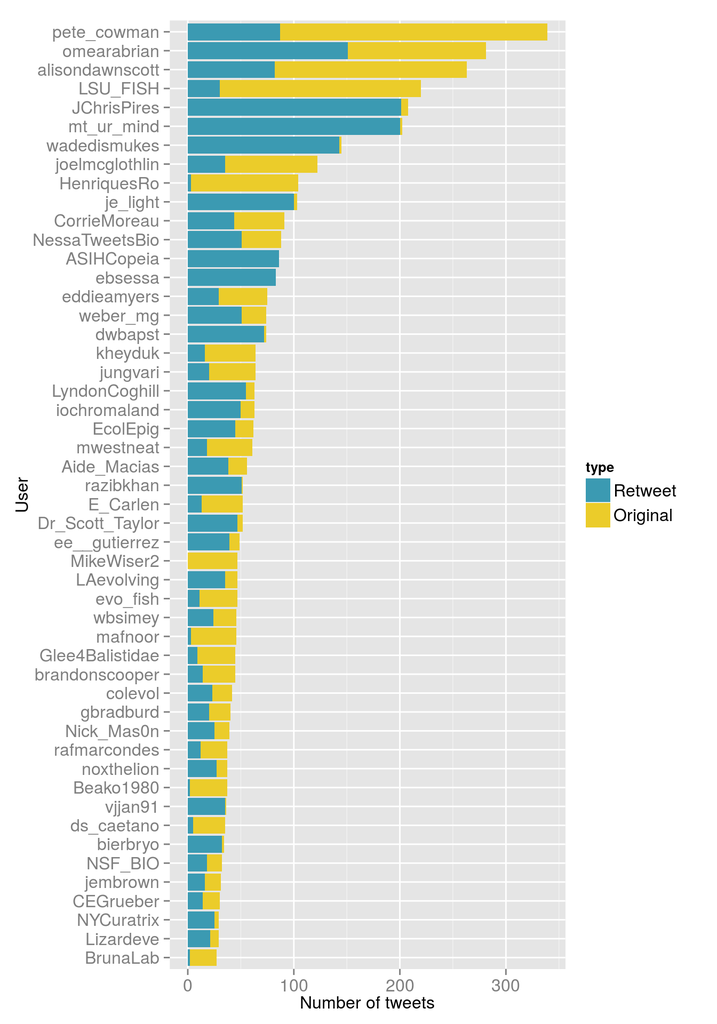

Only for original tweets (retweets excluded)

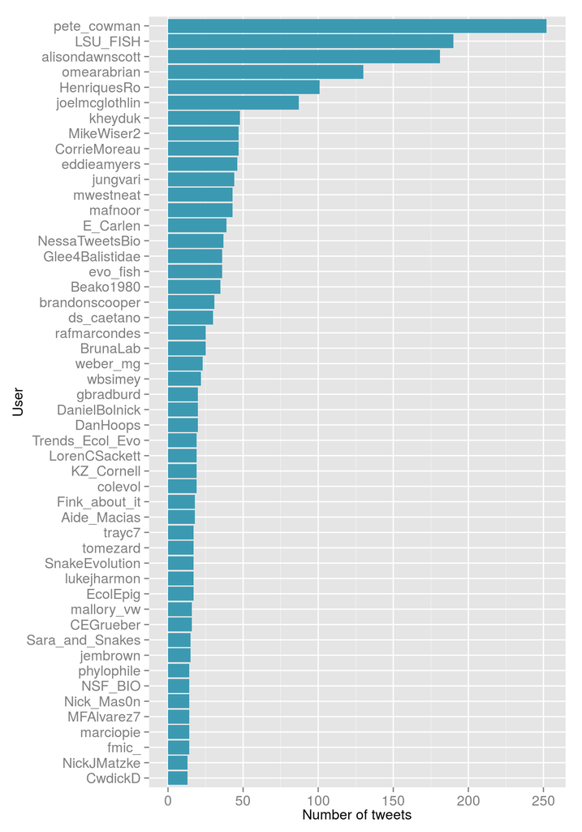

## Most favorited/retweeted users

The figures below only include users who tweeted 5+ times, and don’t include retweets.

### Number of favorites received by users

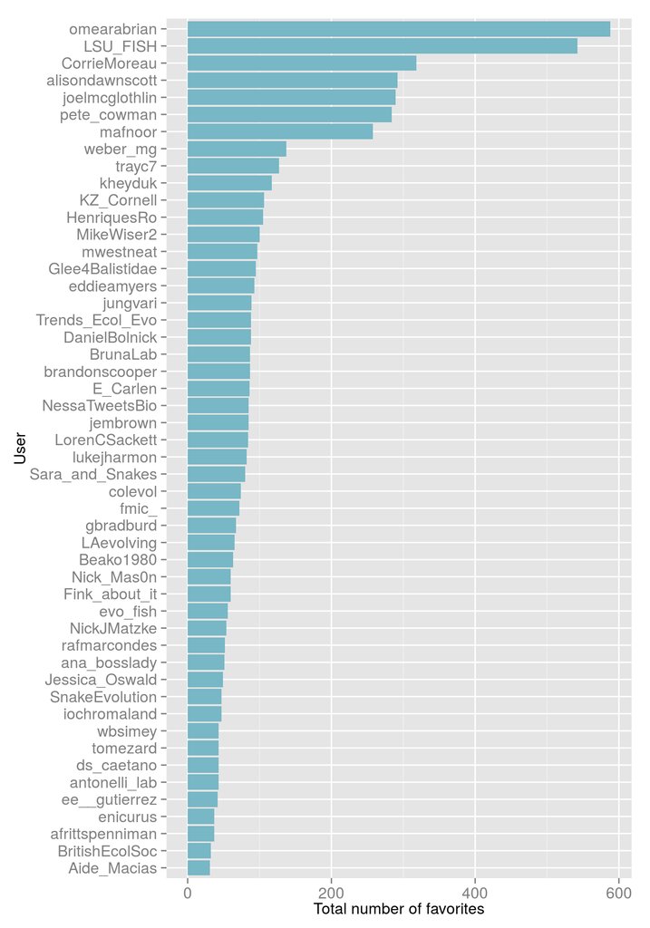

### Number of retweets received by users

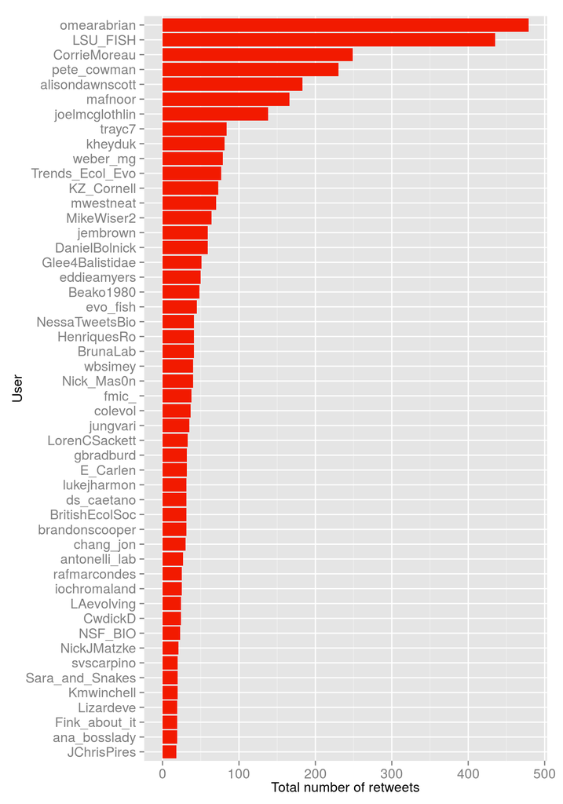

### Mean numbers of favorites received

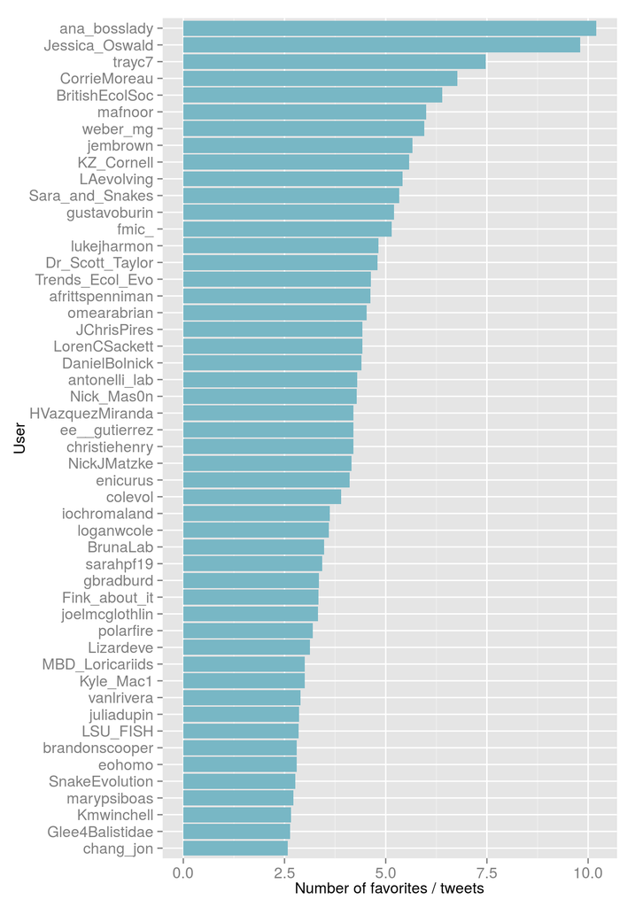

### Mean numbers of retweets received

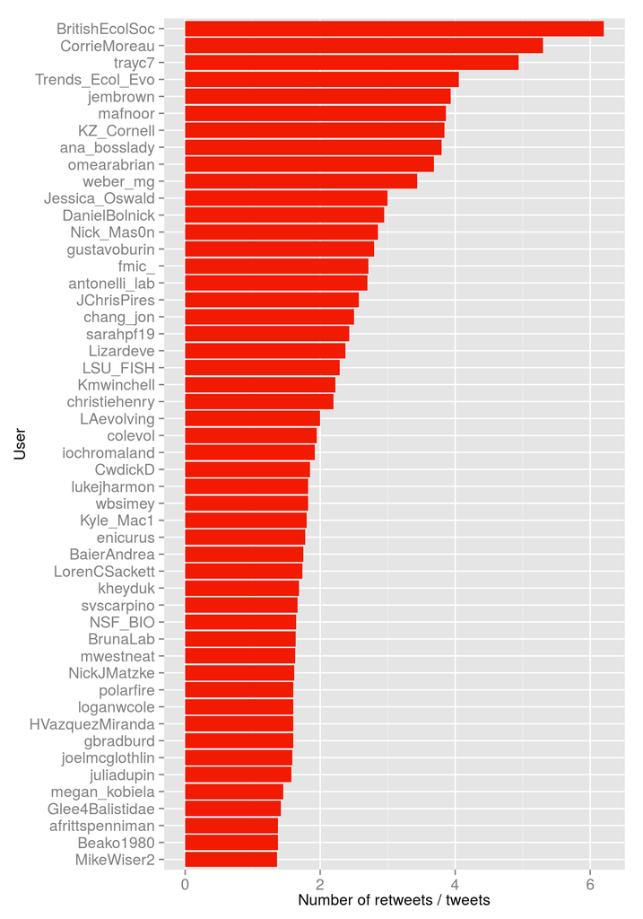

## Word cloud

The top 100 words among the original tweets.

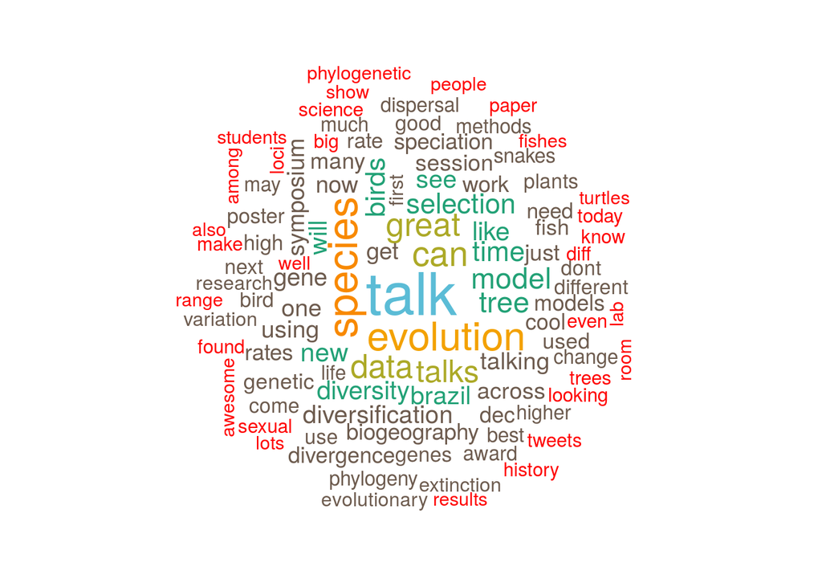

To the extent possible under law, [Francois Michonneau](https://github.com/fmichonneau/evol2015-tweets) has waived all copyright and related or neighboring rights to Summary of tweets at the 2015 Evolution conference. This work is published from: United States.